# Predicting NBA MVP using machine learning

- Khandokar Shakib

Link to webpage https://kshakib22.github.io/kshakib.github.io/

The aim of this project is to predict who the MVP would be for the next season. We will use https://www.basketball-reference.com/ to scrape data and then use it to form our model.

# Cleaning and combining the data

We perform a few data cleaning operations first. Then we combine the mvp, players, and the teams data together for machine learning later.

```python
import pandas as pd
```

We import the different datasets we saved through web-scraping basketball-reference.com.

```python
mvps = pd.read_csv("mvps.csv")
players = pd.read_csv("players.csv")
teams = pd.read_csv("teams.csv")
```

```python
mvps
```

|  | Unnamed: 0 | Rank | Player | Age | Tm | First | Pts Won | Pts Max | Share | G | ... | TRB | AST | STL | BLK | FG% | 3P% | FT% | WS | WS/48 | Year |
| --- | --- | --- | --- | --- | --- | --- | --- | --- | --- | --- | --- | --- | --- | --- | --- | --- | --- | --- | --- | --- | --- |
| 0 | 0 | 1 | Michael Jordan | 27 | CHI | 77.0 | 891.0 | 960 | 0.928 | 82 | ... | 6.0 | 5.5 | 2.7 | 1.0 | 0.539 | 0.312 | 0.851 | 20.3 | 0.321 | 1991 |
| 1 | 1 | 2 | Magic Johnson | 31 | LAL | 10.0 | 497.0 | 960 | 0.518 | 79 | ... | 7.0 | 12.5 | 1.3 | 0.2 | 0.477 | 0.320 | 0.906 | 15.4 | 0.251 | 1991 |
| 2 | 2 | 3 | David Robinson | 25 | SAS | 6.0 | 476.0 | 960 | 0.496 | 82 | ... | 13.0 | 2.5 | 1.5 | 3.9 | 0.552 | 0.143 | 0.762 | 17.0 | 0.264 | 1991 |
| 3 | 3 | 4 | Charles Barkley | 27 | PHI | 2.0 | 222.0 | 960 | 0.231 | 67 | ... | 10.1 | 4.2 | 1.6 | 0.5 | 0.570 | 0.284 | 0.722 | 13.4 | 0.258 | 1991 |
| 4 | 4 | 5 | Karl Malone | 27 | UTA | 0.0 | 142.0 | 960 | 0.148 | 82 | ... | 11.8 | 3.3 | 1.1 | 1.0 | 0.527 | 0.286 | 0.770 | 15.5 | 0.225 | 1991 |
| ... | ... | ... | ... | ... | ... | ... | ... | ... | ... | ... | ... | ... | ... | ... | ... | ... | ... | ... | ... | ... | ... |
| 469 | 10 | 11 | Russell Westbrook | 32 | WAS | 0.0 | 5.0 | 1010 | 0.005 | 65 | ... | 11.5 | 11.7 | 1.4 | 0.4 | 0.439 | 0.315 | 0.656 | 3.7 | 0.075 | 2021 |
| 470 | 11 | 12 | Ben Simmons | 24 | PHI | 0.0 | 3.0 | 1010 | 0.003 | 58 | ... | 7.2 | 6.9 | 1.6 | 0.6 | 0.557 | 0.300 | 0.613 | 6.0 | 0.153 | 2021 |
| 471 | 12 | 13T | James Harden | 31 | TOT | 0.0 | 1.0 | 1010 | 0.001 | 44 | ... | 7.9 | 10.8 | 1.2 | 0.8 | 0.466 | 0.362 | 0.861 | 7.0 | 0.208 | 2021 |
| 472 | 13 | 13T | LeBron James | 36 | LAL | 0.0 | 1.0 | 1010 | 0.001 | 45 | ... | 7.7 | 7.8 | 1.1 | 0.6 | 0.513 | 0.365 | 0.698 | 5.6 | 0.179 | 2021 |
| 473 | 14 | 13T | Kawhi Leonard | 29 | LAC | 0.0 | 1.0 | 1010 | 0.001 | 52 | ... | 6.5 | 5.2 | 1.6 | 0.4 | 0.512 | 0.398 | 0.885 | 8.8 | 0.238 | 2021 |

474 rows × 22 columns

```python
mvps = mvps[["Player", "Year", "Pts Won", "Pts Max", "Share"]]
mvps.head()
```

|  | Player | Year | Pts Won | Pts Max | Share |
| --- | --- | --- | --- | --- | --- |
| 0 | Michael Jordan | 1991 | 891.0 | 960 | 0.928 |
| 1 | Magic Johnson | 1991 | 497.0 | 960 | 0.518 |
| 2 | David Robinson | 1991 | 476.0 | 960 | 0.496 |
| 3 | Charles Barkley | 1991 | 222.0 | 960 | 0.231 |
| 4 | Karl Malone | 1991 | 142.0 | 960 | 0.148 |

```python
players.head()

del players["Unnamed: 0"]

del players["Rk"]

players["Player"] = players["Player"].str.replace("*","", regex=False)

players.head()
```

|  | Player | Pos | Age | Tm | G | GS | MP | FG | FGA | FG% | ... | ORB | DRB | TRB | AST | STL | BLK | TOV | PF | PTS | Year |
| --- | --- | --- | --- | --- | --- | --- | --- | --- | --- | --- | --- | --- | --- | --- | --- | --- | --- | --- | --- | --- | --- |
| 0 | Alaa Abdelnaby | PF | 22 | POR | 43 | 0 | 6.7 | 1.3 | 2.7 | .474 | ... | 0.6 | 1.4 | 2.1 | 0.3 | 0.1 | 0.3 | 0.5 | 0.9 | 3.1 | 1991 |
| 1 | Mahmoud Abdul-Rauf | PG | 21 | DEN | 67 | 19 | 22.5 | 6.2 | 15.1 | .413 | ... | 0.5 | 1.3 | 1.8 | 3.1 | 0.8 | 0.1 | 1.6 | 2.2 | 14.1 | 1991 |
| 2 | Mark Acres | C | 28 | ORL | 68 | 0 | 19.3 | 1.6 | 3.1 | .509 | ... | 2.1 | 3.2 | 5.3 | 0.4 | 0.4 | 0.4 | 0.6 | 3.2 | 4.2 | 1991 |
| 3 | Michael Adams | PG | 28 | DEN | 66 | 66 | 35.5 | 8.5 | 21.5 | .394 | ... | 0.9 | 3.0 | 3.9 | 10.5 | 2.2 | 0.1 | 3.6 | 2.5 | 26.5 | 1991 |
| 4 | Mark Aguirre | SF | 31 | DET | 78 | 13 | 25.7 | 5.4 | 11.7 | .462 | ... | 1.7 | 3.1 | 4.8 | 1.8 | 0.6 | 0.3 | 1.6 | 2.7 | 14.2 | 1991 |

5 rows × 30 columns

```python
players[players["Player"] == "Greg Anderson"]
```

|  | Player | Pos | Age | Tm | G | GS | MP | FG | FGA | FG% | ... | ORB | DRB | TRB | AST | STL | BLK | TOV | PF | PTS | Year |
| --- | --- | --- | --- | --- | --- | --- | --- | --- | --- | --- | --- | --- | --- | --- | --- | --- | --- | --- | --- | --- | --- |
| 8 | Greg Anderson | PF | 26 | TOT | 68 | 2 | 13.6 | 1.7 | 4.0 | .430 | ... | 1.4 | 3.3 | 4.7 | 0.2 | 0.5 | 0.7 | 1.2 | 2.1 | 4.3 | 1991 |
| 9 | Greg Anderson | PF | 26 | MIL | 26 | 0 | 9.5 | 1.0 | 2.8 | .370 | ... | 1.0 | 1.9 | 2.9 | 0.1 | 0.3 | 0.3 | 0.8 | 1.1 | 2.7 | 1991 |
| 10 | Greg Anderson | PF | 26 | NJN | 1 | 0 | 18.0 | 4.0 | 4.0 | 1.000 | ... | 4.0 | 2.0 | 6.0 | 1.0 | 2.0 | 0.0 | 1.0 | 4.0 | 8.0 | 1991 |
| 11 | Greg Anderson | PF | 26 | DEN | 41 | 2 | 16.1 | 2.1 | 4.7 | .440 | ... | 1.6 | 4.1 | 5.8 | 0.3 | 0.6 | 0.9 | 1.5 | 2.6 | 5.2 | 1991 |
| 467 | Greg Anderson | PF | 27 | DEN | 82 | 82 | 34.1 | 4.7 | 10.4 | .456 | ... | 4.1 | 7.4 | 11.5 | 1.0 | 1.1 | 0.8 | 2.5 | 3.2 | 11.5 | 1992 |
| 1412 | Greg Anderson | PF | 29 | DET | 77 | 47 | 21.1 | 2.6 | 4.8 | .543 | ... | 2.4 | 5.0 | 7.4 | 0.7 | 0.7 | 0.9 | 1.2 | 3.0 | 6.4 | 1994 |
| 1911 | Greg Anderson | PF | 30 | ATL | 51 | 0 | 12.2 | 1.1 | 2.0 | .548 | ... | 1.2 | 2.5 | 3.7 | 0.3 | 0.5 | 0.6 | 0.6 | 2.0 | 2.9 | 1995 |
| 2381 | Greg Anderson | PF | 31 | SAS | 46 | 7 | 7.5 | 0.5 | 1.0 | .511 | ... | 0.6 | 1.5 | 2.2 | 0.2 | 0.2 | 0.5 | 0.5 | 1.4 | 1.2 | 1996 |
| 2948 | Greg Anderson | C | 32 | SAS | 82 | 48 | 20.2 | 1.6 | 3.2 | .496 | ... | 1.9 | 3.5 | 5.5 | 0.4 | 0.8 | 0.8 | 0.9 | 2.7 | 3.9 | 1997 |
| 3541 | Greg Anderson | C | 33 | ATL | 50 | 0 | 8.0 | 0.7 | 1.6 | .444 | ... | 0.8 | 1.6 | 2.4 | 0.3 | 0.4 | 0.2 | 0.3 | 1.7 | 1.8 | 1998 |

10 rows × 30 columns

```python
def single_team(df):
    if df.shape[0]==1:
        return df
    else:
        row = df[df["Tm"]=="TOT"]
        row["Tm"] = df.iloc[-1,:]["Tm"]
        return row

players = players.groupby(["Player", "Year"]).apply(single_team)
```

```python
display(players)
```

| Player | Year |  | Player | Pos | Age | Tm | G | GS | MP | FG | FGA | FG% | ... | ORB | DRB | TRB | AST | STL | BLK | TOV | PF | PTS | Year |
| --- | --- | --- | --- | --- | --- | --- | --- | --- | --- | --- | --- | --- | --- | --- | --- | --- | --- | --- | --- | --- | --- | --- | --- |
| A.C. Green | 1991 | 164 | A.C. Green | PF | 27 | LAL | 82 | 21 | 26.4 | 3.1 | 6.6 | .476 | ... | 2.5 | 3.8 | 6.3 | 0.9 | 0.7 | 0.3 | 1.2 | 1.4 | 9.1 | 1991 |
|  | 1992 | 633 | A.C. Green | PF | 28 | LAL | 82 | 53 | 35.4 | 4.7 | 9.8 | .476 | ... | 3.7 | 5.6 | 9.3 | 1.4 | 1.1 | 0.4 | 1.4 | 1.7 | 13.6 | 1992 |
|  | 1993 | 1092 | A.C. Green | PF | 29 | LAL | 82 | 55 | 34.4 | 4.6 | 8.6 | .537 | ... | 3.5 | 5.2 | 8.7 | 1.4 | 1.1 | 0.5 | 1.4 | 1.8 | 12.8 | 1993 |
|  | 1994 | 1579 | A.C. Green | PF | 30 | PHO | 82 | 55 | 34.5 | 5.7 | 11.3 | .502 | ... | 3.4 | 5.8 | 9.2 | 1.7 | 0.9 | 0.5 | 1.2 | 1.7 | 14.7 | 1994 |
|  | 1995 | 2067 | A.C. Green | SF | 31 | PHO | 82 | 52 | 32.8 | 3.8 | 7.5 | .504 | ... | 2.4 | 5.8 | 8.2 | 1.5 | 0.7 | 0.4 | 1.4 | 1.8 | 11.2 | 1995 |
| ... | ... | ... | ... | ... | ... | ... | ... | ... | ... | ... | ... | ... | ... | ... | ... | ... | ... | ... | ... | ... | ... | ... | ... |
| Željko Rebrača | 2002 | 6095 | Željko Rebrača | C | 29 | DET | 74 | 4 | 15.9 | 2.6 | 5.1 | .505 | ... | 1.1 | 2.8 | 3.9 | 0.5 | 0.4 | 1.0 | 1.1 | 2.6 | 6.9 | 2002 |
|  | 2003 | 6595 | Željko Rebrača | C | 30 | DET | 30 | 12 | 16.3 | 2.7 | 4.8 | .552 | ... | 0.9 | 2.2 | 3.1 | 0.3 | 0.2 | 0.6 | 1.0 | 2.6 | 6.6 | 2003 |
|  | 2004 | 7176 | Željko Rebrača | C | 31 | ATL | 24 | 2 | 11.4 | 1.4 | 3.2 | .442 | ... | 1.0 | 1.5 | 2.4 | 0.3 | 0.2 | 0.5 | 0.7 | 2.2 | 3.8 | 2004 |
|  | 2005 | 7776 | Željko Rebrača | C | 32 | LAC | 58 | 2 | 16.0 | 2.3 | 4.0 | .568 | ... | 0.8 | 2.3 | 3.2 | 0.4 | 0.2 | 0.7 | 0.8 | 2.2 | 5.8 | 2005 |
|  | 2006 | 8370 | Željko Rebrača | C | 33 | LAC | 29 | 2 | 14.2 | 1.8 | 3.3 | .542 | ... | 0.4 | 1.8 | 2.2 | 0.3 | 0.2 | 0.7 | 0.8 | 2.0 | 4.7 | 2006 |

14092 rows × 30 columns

```python
players.index = players.index.droplevel()

players.index = players.index.droplevel()
```

```python
players.head()
```

|  | Player | Pos | Age | Tm | G | GS | MP | FG | FGA | FG% | ... | ORB | DRB | TRB | AST | STL | BLK | TOV | PF | PTS | Year |
| --- | --- | --- | --- | --- | --- | --- | --- | --- | --- | --- | --- | --- | --- | --- | --- | --- | --- | --- | --- | --- | --- |
| 164 | A.C. Green | PF | 27 | LAL | 82 | 21 | 26.4 | 3.1 | 6.6 | .476 | ... | 2.5 | 3.8 | 6.3 | 0.9 | 0.7 | 0.3 | 1.2 | 1.4 | 9.1 | 1991 |
| 633 | A.C. Green | PF | 28 | LAL | 82 | 53 | 35.4 | 4.7 | 9.8 | .476 | ... | 3.7 | 5.6 | 9.3 | 1.4 | 1.1 | 0.4 | 1.4 | 1.7 | 13.6 | 1992 |
| 1092 | A.C. Green | PF | 29 | LAL | 82 | 55 | 34.4 | 4.6 | 8.6 | .537 | ... | 3.5 | 5.2 | 8.7 | 1.4 | 1.1 | 0.5 | 1.4 | 1.8 | 12.8 | 1993 |
| 1579 | A.C. Green | PF | 30 | PHO | 82 | 55 | 34.5 | 5.7 | 11.3 | .502 | ... | 3.4 | 5.8 | 9.2 | 1.7 | 0.9 | 0.5 | 1.2 | 1.7 | 14.7 | 1994 |
| 2067 | A.C. Green | SF | 31 | PHO | 82 | 52 | 32.8 | 3.8 | 7.5 | .504 | ... | 2.4 | 5.8 | 8.2 | 1.5 | 0.7 | 0.4 | 1.4 | 1.8 | 11.2 | 1995 |

5 rows × 30 columns

```python
# Rename columns in the players DataFrame
players = players.rename(columns={'Tm': 'Team'})

# Rename columns in the mvps DataFrame
mvps = mvps.rename(columns={'Tm': 'Team'})

combined = players.merge(mvps, how="outer", on=["Player", "Year"])

combined[combined["Pts Won"] > 0]

combined[["Pts Won", "Pts Max", "Share"]] = combined[["Pts Won", "Pts Max", "Share"]].fillna(0)
```

```python
display(combined)
combined.columns
```

|  | Player | Pos | Age | Team | G | GS | MP | FG | FGA | FG% | ... | AST | STL | BLK | TOV | PF | PTS | Year | Pts Won | Pts Max | Share |
| --- | --- | --- | --- | --- | --- | --- | --- | --- | --- | --- | --- | --- | --- | --- | --- | --- | --- | --- | --- | --- | --- |
| 0 | A.C. Green | PF | 27 | LAL | 82 | 21 | 26.4 | 3.1 | 6.6 | .476 | ... | 0.9 | 0.7 | 0.3 | 1.2 | 1.4 | 9.1 | 1991 | 0.0 | 0.0 | 0.0 |
| 1 | A.C. Green | PF | 28 | LAL | 82 | 53 | 35.4 | 4.7 | 9.8 | .476 | ... | 1.4 | 1.1 | 0.4 | 1.4 | 1.7 | 13.6 | 1992 | 0.0 | 0.0 | 0.0 |
| 2 | A.C. Green | PF | 29 | LAL | 82 | 55 | 34.4 | 4.6 | 8.6 | .537 | ... | 1.4 | 1.1 | 0.5 | 1.4 | 1.8 | 12.8 | 1993 | 0.0 | 0.0 | 0.0 |
| 3 | A.C. Green | PF | 30 | PHO | 82 | 55 | 34.5 | 5.7 | 11.3 | .502 | ... | 1.7 | 0.9 | 0.5 | 1.2 | 1.7 | 14.7 | 1994 | 0.0 | 0.0 | 0.0 |
| 4 | A.C. Green | SF | 31 | PHO | 82 | 52 | 32.8 | 3.8 | 7.5 | .504 | ... | 1.5 | 0.7 | 0.4 | 1.4 | 1.8 | 11.2 | 1995 | 0.0 | 0.0 | 0.0 |
| ... | ... | ... | ... | ... | ... | ... | ... | ... | ... | ... | ... | ... | ... | ... | ... | ... | ... | ... | ... | ... | ... |
| 14087 | Željko Rebrača | C | 29 | DET | 74 | 4 | 15.9 | 2.6 | 5.1 | .505 | ... | 0.5 | 0.4 | 1.0 | 1.1 | 2.6 | 6.9 | 2002 | 0.0 | 0.0 | 0.0 |
| 14088 | Željko Rebrača | C | 30 | DET | 30 | 12 | 16.3 | 2.7 | 4.8 | .552 | ... | 0.3 | 0.2 | 0.6 | 1.0 | 2.6 | 6.6 | 2003 | 0.0 | 0.0 | 0.0 |
| 14089 | Željko Rebrača | C | 31 | ATL | 24 | 2 | 11.4 | 1.4 | 3.2 | .442 | ... | 0.3 | 0.2 | 0.5 | 0.7 | 2.2 | 3.8 | 2004 | 0.0 | 0.0 | 0.0 |
| 14090 | Željko Rebrača | C | 32 | LAC | 58 | 2 | 16.0 | 2.3 | 4.0 | .568 | ... | 0.4 | 0.2 | 0.7 | 0.8 | 2.2 | 5.8 | 2005 | 0.0 | 0.0 | 0.0 |
| 14091 | Željko Rebrača | C | 33 | LAC | 29 | 2 | 14.2 | 1.8 | 3.3 | .542 | ... | 0.3 | 0.2 | 0.7 | 0.8 | 2.0 | 4.7 | 2006 | 0.0 | 0.0 | 0.0 |

14092 rows × 33 columns

```
Index(['Player', 'Pos', 'Age', 'Team', 'G', 'GS', 'MP', 'FG', 'FGA', 'FG%',
       '3P', '3PA', '3P%', '2P', '2PA', '2P%', 'eFG%', 'FT', 'FTA', 'FT%',
       'ORB', 'DRB', 'TRB', 'AST', 'STL', 'BLK', 'TOV', 'PF', 'PTS', 'Year',
       'Pts Won', 'Pts Max', 'Share'],
      dtype='object')
```

```python
teams
```

|  | Unnamed: 0 | W | L | W/L% | GB | PS/G | PA/G | SRS | Year | Team |
| --- | --- | --- | --- | --- | --- | --- | --- | --- | --- | --- |
| 0 | 0 | 56 | 26 | .683 | — | 111.5 | 105.7 | 5.22 | 1991 | Boston Celtics* |
| 1 | 1 | 44 | 38 | .537 | 12.0 | 105.4 | 105.6 | -0.39 | 1991 | Philadelphia 76ers* |
| 2 | 2 | 39 | 43 | .476 | 17.0 | 103.1 | 103.3 | -0.43 | 1991 | New York Knicks* |
| 3 | 3 | 30 | 52 | .366 | 26.0 | 101.4 | 106.4 | -4.84 | 1991 | Washington Bullets |
| 4 | 4 | 26 | 56 | .317 | 30.0 | 102.9 | 107.5 | -4.53 | 1991 | New Jersey Nets |
| ... | ... | ... | ... | ... | ... | ... | ... | ... | ... | ... |
| 1028 | 13 | 42 | 30 | .583 | — | 112.4 | 110.2 | 2.26 | 2021 | Dallas Mavericks* |
| 1029 | 14 | 38 | 34 | .528 | 4.0 | 113.3 | 112.3 | 1.07 | 2021 | Memphis Grizzlies* |
| 1030 | 15 | 33 | 39 | .458 | 9.0 | 111.1 | 112.8 | -1.58 | 2021 | San Antonio Spurs |
| 1031 | 16 | 31 | 41 | .431 | 11.0 | 114.6 | 114.9 | -0.20 | 2021 | New Orleans Pelicans |
| 1032 | 17 | 17 | 55 | .236 | 25.0 | 108.8 | 116.7 | -7.50 | 2021 | Houston Rockets |

1033 rows × 10 columns

```python
teams = teams[~teams["W"].str.contains("Division")].copy()

teams["Team"] = teams["Team"].str.replace("*", "", regex=False)

sorted(teams["Team"].unique())
```

```
['Atlanta Hawks',
 'Boston Celtics',
 'Brooklyn Nets',
 'Charlotte Bobcats',
 'Charlotte Hornets',
 'Chicago Bulls',
 'Cleveland Cavaliers',
 'Dallas Mavericks',
 'Denver Nuggets',
 'Detroit Pistons',
 'Golden State Warriors',
 'Houston Rockets',
 'Indiana Pacers',
 'Los Angeles Clippers',
 'Los Angeles Lakers',
 'Memphis Grizzlies',
 'Miami Heat',
 'Milwaukee Bucks',
 'Minnesota Timberwolves',
 'New Jersey Nets',
 'New Orleans Hornets',
 'New Orleans Pelicans',
 'New Orleans/Oklahoma City Hornets',
 'New York Knicks',
 'Oklahoma City Thunder',
 'Orlando Magic',
 'Philadelphia 76ers',
 'Phoenix Suns',
 'Portland Trail Blazers',
 'Sacramento Kings',
 'San Antonio Spurs',
 'Seattle SuperSonics',
 'Toronto Raptors',
 'Utah Jazz',
 'Vancouver Grizzlies',
 'Washington Bullets',
 'Washington Wizards']
```

```python
sorted(combined["Team"].unique())
```

```
['ATL',
 'BOS',
 'BRK',
 'CHA',
 'CHH',
 'CHI',
 'CHO',
 'CLE',
 'DAL',
 'DEN',
 'DET',
 'GSW',
 'HOU',
 'IND',
 'LAC',
 'LAL',
 'MEM',
 'MIA',
 'MIL',
 'MIN',
 'NJN',
 'NOH',
 'NOK',
 'NOP',
 'NYK',
 'OKC',
 'ORL',
 'PHI',
 'PHO',
 'POR',
 'SAC',
 'SAS',
 'SEA',
 'TOR',
 'UTA',
 'VAN',
 'WAS',
 'WSB']
```

The team names between teams and combined dataframe is in different formats. One contains only abbreviations and other contain full names. We read in a file called nicknames.csv which contains the team abbreviation followed by its full name. We convert it into dictionary so that each abbreviation maps to the team name.

```python
nicknames = {}
with open("nicknames.csv") as f:
    lines = f.readlines()
    for line in lines[1:]:
        abbrev,name = line.replace("\n","").split(",")
        nicknames[abbrev] = name

combined["Team"] = combined["Team"].map(nicknames)
```

```python
nicknames
```

```
{'ATL': 'Atlanta Hawks',
 'BRK': 'Brooklyn Nets',
 'BKN': 'Brooklyn Nets',
 'BOS': 'Boston Celtics',
 'CHA': 'Charlotte Bobcats',
 'CHH': 'Charlotte Hornets',
 'CHO': 'Charlotte Hornets',
 'CHI': 'Chicago Bulls',
 'CLE': 'Cleveland Cavaliers',
 'DAL': 'Dallas Mavericks',
 'DEN': 'Denver Nuggets',
 'DET': 'Detroit Pistons',
 'GSW': 'Golden State Warriors',
 'HOU': 'Houston Rockets',
 'IND': 'Indiana Pacers',
 'LAC': 'Los Angeles Clippers',
 'LAL': 'Los Angeles Lakers',
 'MEM': 'Memphis Grizzlies',
 'MIA': 'Miami Heat',
 'MIL': 'Milwaukee Bucks',
 'MIN': 'Minnesota Timberwolves',
 'NJN': 'New Jersey Nets',
 'NOH': 'New Orleans Hornets',
 'NOP': 'New Orleans Pelicans',
 'NOK': 'New Orleans/Oklahoma City Hornets',
 'NYK': 'New York Knicks',
 'OKC': 'Oklahoma City Thunder',
 'ORL': 'Orlando Magic',
 'PHI': 'Philadelphia 76ers',
 'PHX': 'Phoenix Suns',
 'PHO': 'Phoenix Suns',
 'POR': 'Portland Trail Blazers',
 'SEA': 'Seattle SuperSonics',
 'SAC': 'Sacramento Kings',
 'SAS': 'San Antonio Spurs',
 'TOR': 'Toronto Raptors',
 'UTA': 'Utah Jazz',
 'VAN': 'Vancouver Grizzlies',
 'WAS': 'Washington Wizards',
 'WSB': 'Washington Bullets'}
```

```python
combined.head()
```

|  | Player | Pos | Age | Team | G | GS | MP | FG | FGA | FG% | ... | AST | STL | BLK | TOV | PF | PTS | Year | Pts Won | Pts Max | Share |
| --- | --- | --- | --- | --- | --- | --- | --- | --- | --- | --- | --- | --- | --- | --- | --- | --- | --- | --- | --- | --- | --- |
| 0 | A.C. Green | PF | 27 | Los Angeles Lakers | 82 | 21 | 26.4 | 3.1 | 6.6 | .476 | ... | 0.9 | 0.7 | 0.3 | 1.2 | 1.4 | 9.1 | 1991 | 0.0 | 0.0 | 0.0 |
| 1 | A.C. Green | PF | 28 | Los Angeles Lakers | 82 | 53 | 35.4 | 4.7 | 9.8 | .476 | ... | 1.4 | 1.1 | 0.4 | 1.4 | 1.7 | 13.6 | 1992 | 0.0 | 0.0 | 0.0 |
| 2 | A.C. Green | PF | 29 | Los Angeles Lakers | 82 | 55 | 34.4 | 4.6 | 8.6 | .537 | ... | 1.4 | 1.1 | 0.5 | 1.4 | 1.8 | 12.8 | 1993 | 0.0 | 0.0 | 0.0 |
| 3 | A.C. Green | PF | 30 | Phoenix Suns | 82 | 55 | 34.5 | 5.7 | 11.3 | .502 | ... | 1.7 | 0.9 | 0.5 | 1.2 | 1.7 | 14.7 | 1994 | 0.0 | 0.0 | 0.0 |
| 4 | A.C. Green | SF | 31 | Phoenix Suns | 82 | 52 | 32.8 | 3.8 | 7.5 | .504 | ... | 1.5 | 0.7 | 0.4 | 1.4 | 1.8 | 11.2 | 1995 | 0.0 | 0.0 | 0.0 |

5 rows × 33 columns

```python
train = combined.merge(teams, how="outer", on=["Team", "Year"], left_index=False, right_index=False)
```

```python
del train["Unnamed: 0"]
```

```python
train
```

|  | Player | Pos | Age | Team | G | GS | MP | FG | FGA | FG% | ... | Pts Won | Pts Max | Share | W | L | W/L% | GB | PS/G | PA/G | SRS |
| --- | --- | --- | --- | --- | --- | --- | --- | --- | --- | --- | --- | --- | --- | --- | --- | --- | --- | --- | --- | --- | --- |
| 0 | A.C. Green | PF | 27 | Los Angeles Lakers | 82 | 21 | 26.4 | 3.1 | 6.6 | .476 | ... | 0.0 | 0.0 | 0.0 | 58 | 24 | .707 | 5.0 | 106.3 | 99.6 | 6.73 |
| 1 | Byron Scott | SG | 29 | Los Angeles Lakers | 82 | 82 | 32.1 | 6.1 | 12.8 | .477 | ... | 0.0 | 0.0 | 0.0 | 58 | 24 | .707 | 5.0 | 106.3 | 99.6 | 6.73 |
| 2 | Elden Campbell | PF | 22 | Los Angeles Lakers | 52 | 0 | 7.3 | 1.1 | 2.4 | .455 | ... | 0.0 | 0.0 | 0.0 | 58 | 24 | .707 | 5.0 | 106.3 | 99.6 | 6.73 |
| 3 | Irving Thomas | PF | 25 | Los Angeles Lakers | 26 | 0 | 4.2 | 0.7 | 1.9 | .340 | ... | 0.0 | 0.0 | 0.0 | 58 | 24 | .707 | 5.0 | 106.3 | 99.6 | 6.73 |
| 4 | James Worthy | SF | 29 | Los Angeles Lakers | 78 | 74 | 38.6 | 9.2 | 18.7 | .492 | ... | 0.0 | 0.0 | 0.0 | 58 | 24 | .707 | 5.0 | 106.3 | 99.6 | 6.73 |
| ... | ... | ... | ... | ... | ... | ... | ... | ... | ... | ... | ... | ... | ... | ... | ... | ... | ... | ... | ... | ... | ... |
| 14087 | Spencer Hawes | PF | 28 | Milwaukee Bucks | 54 | 1 | 14.8 | 2.5 | 5.1 | .484 | ... | 0.0 | 0.0 | 0.0 | 42 | 40 | .512 | 9.0 | 103.6 | 103.8 | -0.45 |
| 14088 | Steve Novak | PF | 33 | Milwaukee Bucks | 8 | 0 | 2.8 | 0.3 | 0.9 | .286 | ... | 0.0 | 0.0 | 0.0 | 42 | 40 | .512 | 9.0 | 103.6 | 103.8 | -0.45 |
| 14089 | Terrence Jones | PF | 25 | Milwaukee Bucks | 54 | 12 | 23.5 | 4.3 | 9.1 | .470 | ... | 0.0 | 0.0 | 0.0 | 42 | 40 | .512 | 9.0 | 103.6 | 103.8 | -0.45 |
| 14090 | Thon Maker | C | 19 | Milwaukee Bucks | 57 | 34 | 9.9 | 1.5 | 3.2 | .459 | ... | 0.0 | 0.0 | 0.0 | 42 | 40 | .512 | 9.0 | 103.6 | 103.8 | -0.45 |
| 14091 | Tony Snell | SG | 25 | Milwaukee Bucks | 80 | 80 | 29.2 | 3.1 | 6.8 | .455 | ... | 0.0 | 0.0 | 0.0 | 42 | 40 | .512 | 9.0 | 103.6 | 103.8 | -0.45 |

14092 rows × 40 columns

```python
train.dtypes
```

```
Player      object
Pos         object
Age         object
Team        object
G           object
GS          object
MP          object
FG          object
FGA         object
FG%         object
3P          object
3PA         object
3P%         object
2P          object
2PA         object
2P%         object
eFG%        object
FT          object
FTA         object
FT%         object
ORB         object
DRB         object
TRB         object
AST         object
STL         object
BLK         object
TOV         object
PF          object
PTS         object
Year         int64
Pts Won    float64
Pts Max    float64
Share      float64
W           object
L           object
W/L%        object
GB          object
PS/G        object
PA/G        object
SRS         object
dtype: object
```

We convert numerical columns into numeric type

```python
train = train.apply(pd.to_numeric, errors='ignore')
```

```python
train.dtypes
```

```
Player      object
Pos         object
Age          int64
Team        object
G            int64
GS           int64
MP         float64
FG         float64
FGA        float64
FG%        float64
3P         float64
3PA        float64
3P%        float64
2P         float64
2PA        float64
2P%        float64
eFG%       float64
FT         float64
FTA        float64
FT%        float64
ORB        float64
DRB        float64
TRB        float64
AST        float64
STL        float64
BLK        float64
TOV        float64
PF         float64
PTS        float64
Year         int64
Pts Won    float64
Pts Max    float64
Share      float64
W            int64
L            int64
W/L%       float64
GB          object
PS/G       float64
PA/G       float64
SRS        float64
dtype: object
```

```python
train["GB"].unique()
```

```
array(['5.0', '14.0', '23.0', '7.0', '—', '40.0', '42.0', '18.0', '6.0',
       '24.0', '26.0', '37.0', '29.0', '21.0', '28.0', '25.0', '8.0',
       '19.0', '1.0', '13.0', '17.0', '3.0', '15.0', '9.0', '2.0', '35.0',
       '20.0', '11.0', '16.0', '41.0', '12.0', '50.0', '10.0', '30.0',
       '34.0', '4.0', '1.5', '22.0', '51.0', '36.0', '43.0', '39.0',
       '18.5', '48.0', '46.0', '10.5', '32.0', '38.0', '27.0', '33.0',
       '31.0', '21.5', '45.0', '22.5', '25.5', '3.5', '20.5', '11.5',
       '44.0', '52.0', '56.0', '2.5', '12.5', '47.0', '32.5', '4.5'],
      dtype=object)
```

```python
train["GB"] = pd.to_numeric(train["GB"].str.replace("—","0"))
```

```python
train.dtypes
```

```
Player      object
Pos         object
Age          int64
Team        object
G            int64
GS           int64
MP         float64
FG         float64
FGA        float64
FG%        float64
3P         float64
3PA        float64
3P%        float64
2P         float64
2PA        float64
2P%        float64
eFG%       float64
FT         float64
FTA        float64
FT%        float64
ORB        float64
DRB        float64
TRB        float64
AST        float64
STL        float64
BLK        float64
TOV        float64
PF         float64
PTS        float64
Year         int64
Pts Won    float64
Pts Max    float64
Share      float64
W            int64
L            int64
W/L%       float64
GB         float64
PS/G       float64
PA/G       float64
SRS        float64
dtype: object
```

We have gathered and cleaned all the data required for our machine learning requirements. We save this cleaned data as a csv file named 'player_mvp_stats.csv'

```python
train.to_csv("player_mvp_stats.csv")
```

# Exploring the training data

```python
highest_scoring = train[train["G"] > 70].sort_values("PTS", ascending=False).head(10)
```

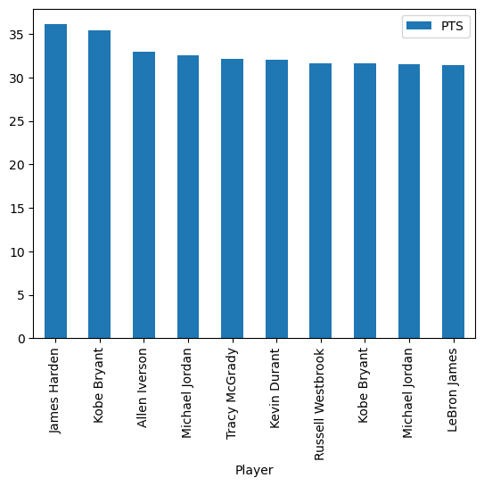

```python
highest_scoring.plot.bar("Player", "PTS")
```

We find who scored the highest each year, sort each of the group by points.

```python
highest_scoring_by_year = train.groupby("Year").apply(lambda x: x.sort_values("PTS", ascending=False).head(1))
display(highest_scoring_by_year)
```

| Year |  | Player | Pos | Age | Team | G | GS | MP | FG | FGA | FG% | ... | Pts Won | Pts Max | Share | W | L | W/L% | GB | PS/G | PA/G | SRS |
| --- | --- | --- | --- | --- | --- | --- | --- | --- | --- | --- | --- | --- | --- | --- | --- | --- | --- | --- | --- | --- | --- | --- |
| 1991 | 9927 | Michael Jordan | SG | 27 | Chicago Bulls | 82 | 82 | 37.0 | 12.1 | 22.4 | 0.539 | ... | 891.0 | 960.0 | 0.928 | 61 | 21 | 0.744 | 0.0 | 110.0 | 101.0 | 8.57 |
| 1992 | 9940 | Michael Jordan | SG | 28 | Chicago Bulls | 80 | 80 | 38.8 | 11.8 | 22.7 | 0.519 | ... | 900.0 | 960.0 | 0.938 | 67 | 15 | 0.817 | 0.0 | 109.9 | 99.5 | 10.07 |
| 1993 | 9953 | Michael Jordan | SG | 29 | Chicago Bulls | 78 | 78 | 39.3 | 12.7 | 25.7 | 0.495 | ... | 565.0 | 980.0 | 0.577 | 57 | 25 | 0.695 | 0.0 | 105.2 | 98.9 | 6.19 |
| 1994 | 8684 | David Robinson | C | 28 | San Antonio Spurs | 80 | 80 | 40.5 | 10.5 | 20.7 | 0.507 | ... | 730.0 | 1010.0 | 0.723 | 55 | 27 | 0.671 | 3.0 | 100.0 | 94.8 | 5.05 |
| 1995 | 7348 | Shaquille O'Neal | C | 22 | Orlando Magic | 79 | 79 | 37.0 | 11.8 | 20.2 | 0.583 | ... | 605.0 | 1050.0 | 0.576 | 57 | 25 | 0.695 | 0.0 | 110.9 | 103.8 | 6.44 |
| 1996 | 10510 | Michael Jordan | SG | 32 | Chicago Bulls | 82 | 82 | 37.7 | 11.2 | 22.6 | 0.495 | ... | 1114.0 | 1130.0 | 0.986 | 72 | 10 | 0.878 | 0.0 | 105.2 | 92.9 | 11.80 |
| 1997 | 10524 | Michael Jordan | SG | 33 | Chicago Bulls | 82 | 82 | 37.9 | 11.2 | 23.1 | 0.486 | ... | 957.0 | 1150.0 | 0.832 | 69 | 13 | 0.841 | 0.0 | 103.1 | 92.3 | 10.70 |
| 1998 | 10538 | Michael Jordan | SG | 34 | Chicago Bulls | 82 | 82 | 38.8 | 10.7 | 23.1 | 0.465 | ... | 1084.0 | 1160.0 | 0.934 | 62 | 20 | 0.756 | 0.0 | 96.7 | 89.6 | 7.24 |
| 1999 | 937 | Allen Iverson | SG | 23 | Philadelphia 76ers | 48 | 48 | 41.5 | 9.1 | 22.0 | 0.412 | ... | 319.0 | 1180.0 | 0.270 | 28 | 22 | 0.560 | 5.0 | 89.7 | 87.6 | 2.56 |
| 2000 | 143 | Shaquille O'Neal | C | 27 | Los Angeles Lakers | 79 | 79 | 40.0 | 12.1 | 21.1 | 0.574 | ... | 1207.0 | 1210.0 | 0.998 | 67 | 15 | 0.817 | 0.0 | 100.8 | 92.3 | 8.41 |
| 2001 | 968 | Allen Iverson | SG | 25 | Philadelphia 76ers | 71 | 71 | 42.0 | 10.7 | 25.5 | 0.420 | ... | 1121.0 | 1240.0 | 0.904 | 56 | 26 | 0.683 | 0.0 | 94.7 | 90.4 | 3.64 |
| 2002 | 984 | Allen Iverson | SG | 26 | Philadelphia 76ers | 60 | 59 | 43.7 | 11.1 | 27.8 | 0.398 | ... | 29.0 | 1260.0 | 0.023 | 43 | 39 | 0.524 | 9.0 | 91.0 | 89.4 | 1.27 |
| 2003 | 6871 | Tracy McGrady | SG | 23 | Orlando Magic | 75 | 74 | 39.4 | 11.1 | 24.2 | 0.457 | ... | 427.0 | 1190.0 | 0.359 | 42 | 40 | 0.512 | 7.0 | 98.5 | 98.4 | -0.39 |
| 2004 | 6884 | Tracy McGrady | SG | 24 | Orlando Magic | 67 | 67 | 39.9 | 9.7 | 23.4 | 0.417 | ... | 0.0 | 0.0 | 0.000 | 21 | 61 | 0.256 | 26.0 | 94.0 | 101.1 | -7.25 |
| 2005 | 1031 | Allen Iverson | PG | 29 | Philadelphia 76ers | 75 | 75 | 42.3 | 10.3 | 24.2 | 0.424 | ... | 240.0 | 1270.0 | 0.189 | 43 | 39 | 0.524 | 2.0 | 99.1 | 99.9 | -1.07 |
| 2006 | 1051 | Kobe Bryant | SG | 27 | Los Angeles Lakers | 80 | 80 | 41.0 | 12.2 | 27.2 | 0.450 | ... | 483.0 | 1250.0 | 0.386 | 45 | 37 | 0.549 | 9.0 | 99.4 | 96.9 | 2.53 |
| 2007 | 1065 | Kobe Bryant | SG | 28 | Los Angeles Lakers | 77 | 77 | 40.8 | 10.6 | 22.8 | 0.463 | ... | 521.0 | 1290.0 | 0.404 | 42 | 40 | 0.512 | 19.0 | 103.3 | 103.4 | 0.24 |
| 2008 | 5513 | LeBron James | SF | 23 | Cleveland Cavaliers | 75 | 74 | 40.4 | 10.6 | 21.9 | 0.484 | ... | 438.0 | 1260.0 | 0.348 | 45 | 37 | 0.549 | 14.0 | 96.4 | 96.7 | -0.53 |
| 2009 | 13198 | Dwyane Wade | SG | 27 | Miami Heat | 79 | 79 | 38.6 | 10.8 | 22.0 | 0.491 | ... | 680.0 | 1210.0 | 0.562 | 43 | 39 | 0.524 | 16.0 | 98.3 | 98.0 | 0.49 |
| 2010 | 8835 | Kevin Durant | SF | 21 | Oklahoma City Thunder | 82 | 82 | 39.5 | 9.7 | 20.3 | 0.476 | ... | 609.0 | 1230.0 | 0.495 | 50 | 32 | 0.610 | 3.0 | 101.5 | 98.0 | 3.55 |
| 2011 | 12528 | Kevin Durant | SF | 22 | Oklahoma City Thunder | 78 | 78 | 38.9 | 9.1 | 19.7 | 0.462 | ... | 190.0 | 1210.0 | 0.157 | 55 | 27 | 0.671 | 0.0 | 104.8 | 101.0 | 3.81 |
| 2012 | 13413 | Kevin Durant | SF | 23 | Oklahoma City Thunder | 66 | 66 | 38.6 | 9.7 | 19.7 | 0.496 | ... | 889.0 | 1210.0 | 0.735 | 47 | 19 | 0.712 | 0.0 | 103.1 | 96.9 | 6.44 |
| 2013 | 5256 | Carmelo Anthony | PF | 28 | New York Knicks | 67 | 67 | 37.0 | 10.0 | 22.2 | 0.449 | ... | 475.0 | 1210.0 | 0.393 | 54 | 28 | 0.659 | 0.0 | 100.0 | 95.7 | 3.73 |
| 2014 | 6300 | Kevin Durant | SF | 25 | Oklahoma City Thunder | 81 | 81 | 38.5 | 10.5 | 20.8 | 0.503 | ... | 1232.0 | 1250.0 | 0.986 | 59 | 23 | 0.720 | 0.0 | 106.2 | 99.8 | 6.66 |
| 2015 | 6323 | Russell Westbrook | PG | 26 | Oklahoma City Thunder | 67 | 67 | 34.4 | 9.4 | 22.0 | 0.426 | ... | 352.0 | 1300.0 | 0.271 | 45 | 37 | 0.549 | 6.0 | 104.0 | 101.8 | 2.47 |
| 2016 | 5562 | Stephen Curry | PG | 27 | Golden State Warriors | 79 | 79 | 34.2 | 10.2 | 20.2 | 0.504 | ... | 1310.0 | 1310.0 | 1.000 | 73 | 9 | 0.890 | 0.0 | 114.9 | 104.1 | 10.38 |
| 2017 | 6352 | Russell Westbrook | PG | 28 | Oklahoma City Thunder | 81 | 81 | 34.6 | 10.2 | 24.0 | 0.425 | ... | 888.0 | 1010.0 | 0.879 | 47 | 35 | 0.573 | 4.0 | 106.6 | 105.8 | 1.14 |
| 2018 | 867 | James Harden | SG | 28 | Houston Rockets | 72 | 72 | 35.4 | 9.0 | 20.1 | 0.449 | ... | 965.0 | 1010.0 | 0.955 | 65 | 17 | 0.793 | 0.0 | 112.4 | 103.9 | 8.21 |
| 2019 | 9634 | James Harden | PG | 29 | Houston Rockets | 78 | 78 | 36.8 | 10.8 | 24.5 | 0.442 | ... | 776.0 | 1010.0 | 0.768 | 53 | 29 | 0.646 | 0.0 | 113.9 | 109.1 | 4.96 |
| 2020 | 9651 | James Harden | SG | 30 | Houston Rockets | 68 | 68 | 36.5 | 9.9 | 22.3 | 0.444 | ... | 367.0 | 1010.0 | 0.363 | 44 | 28 | 0.611 | 0.0 | 117.8 | 114.8 | 3.13 |
| 2021 | 3651 | Stephen Curry | PG | 32 | Golden State Warriors | 63 | 63 | 34.2 | 10.4 | 21.7 | 0.482 | ... | 453.0 | 1010.0 | 0.449 | 39 | 33 | 0.542 | 12.0 | 113.7 | 112.7 | 1.10 |

31 rows × 40 columns

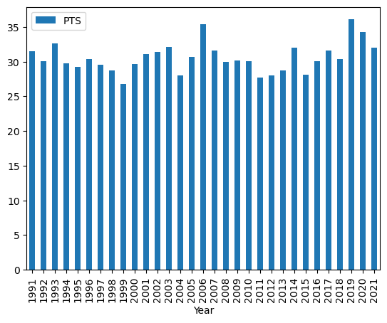

```python
highest_scoring_by_year.plot.bar("Year", "PTS")
```

```python
train.groupby("Year").apply(lambda x: x.shape[0])
```

```
Year
1991    385
1992    386
1993    390
1994    403
1995    405
1996    428
1997    441
1998    439
1999    440
2000    439
2001    441
2002    440
2003    428
2004    442
```

[output cut: 18 more lines]

```python
train.corr()["Share"]
```

```
Age        0.018596
G          0.089282
GS         0.167476
MP         0.162175
FG         0.276365
FGA        0.249254
FG%        0.065789
3P         0.096225
3PA        0.096460
3P%        0.013611
2P         0.275976
2PA        0.251885
2P%        0.063240
eFG%       0.059335
FT         0.316392
FTA        0.321457
FT%        0.037875
ORB        0.101375
DRB        0.213241
TRB        0.186209
AST        0.200253
STL        0.175041
BLK        0.154713
TOV        0.233015
PF         0.071046
PTS        0.288267
Year      -0.008135
Pts Won    0.995153
Pts Max    0.521335
Share      1.000000
W          0.122718
L         -0.121866
W/L%       0.126559
GB        -0.101014
PS/G       0.045206
PA/G      -0.039617
SRS        0.122782
Name: Share, dtype: float64
```

Here we see which factors correlate the most with becoming MVP.

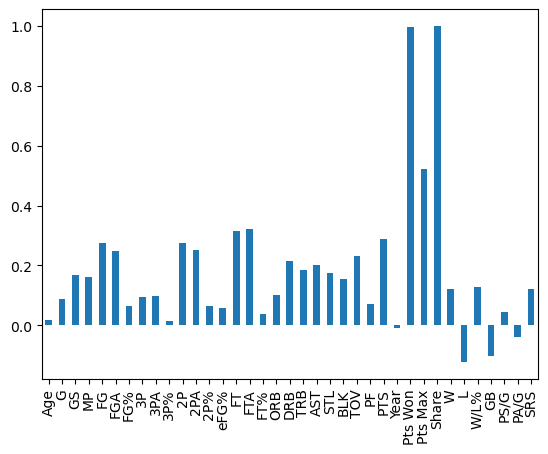

```python
train.corr()["Share"].plot.bar()
```

Each row represents a player in NBA in our stats file. All the per game stats for each player is used to predict how many points the player would have earned in NBA voting. We are predicting the 'Share' which is the share of votes received for NBA MVP.

```python
stats = pd.read_csv("player_mvp_stats.csv", index_col=0)
display(stats)
```

|  | Player | Pos | Age | Team | G | GS | MP | FG | FGA | FG% | ... | Pts Won | Pts Max | Share | W | L | W/L% | GB | PS/G | PA/G | SRS |
| --- | --- | --- | --- | --- | --- | --- | --- | --- | --- | --- | --- | --- | --- | --- | --- | --- | --- | --- | --- | --- | --- |
| 0 | A.C. Green | PF | 27 | Los Angeles Lakers | 82 | 21 | 26.4 | 3.1 | 6.6 | 0.476 | ... | 0.0 | 0.0 | 0.0 | 58 | 24 | 0.707 | 5.0 | 106.3 | 99.6 | 6.73 |
| 1 | Byron Scott | SG | 29 | Los Angeles Lakers | 82 | 82 | 32.1 | 6.1 | 12.8 | 0.477 | ... | 0.0 | 0.0 | 0.0 | 58 | 24 | 0.707 | 5.0 | 106.3 | 99.6 | 6.73 |
| 2 | Elden Campbell | PF | 22 | Los Angeles Lakers | 52 | 0 | 7.3 | 1.1 | 2.4 | 0.455 | ... | 0.0 | 0.0 | 0.0 | 58 | 24 | 0.707 | 5.0 | 106.3 | 99.6 | 6.73 |
| 3 | Irving Thomas | PF | 25 | Los Angeles Lakers | 26 | 0 | 4.2 | 0.7 | 1.9 | 0.340 | ... | 0.0 | 0.0 | 0.0 | 58 | 24 | 0.707 | 5.0 | 106.3 | 99.6 | 6.73 |
| 4 | James Worthy | SF | 29 | Los Angeles Lakers | 78 | 74 | 38.6 | 9.2 | 18.7 | 0.492 | ... | 0.0 | 0.0 | 0.0 | 58 | 24 | 0.707 | 5.0 | 106.3 | 99.6 | 6.73 |
| ... | ... | ... | ... | ... | ... | ... | ... | ... | ... | ... | ... | ... | ... | ... | ... | ... | ... | ... | ... | ... | ... |
| 14087 | Spencer Hawes | PF | 28 | Milwaukee Bucks | 54 | 1 | 14.8 | 2.5 | 5.1 | 0.484 | ... | 0.0 | 0.0 | 0.0 | 42 | 40 | 0.512 | 9.0 | 103.6 | 103.8 | -0.45 |
| 14088 | Steve Novak | PF | 33 | Milwaukee Bucks | 8 | 0 | 2.8 | 0.3 | 0.9 | 0.286 | ... | 0.0 | 0.0 | 0.0 | 42 | 40 | 0.512 | 9.0 | 103.6 | 103.8 | -0.45 |
| 14089 | Terrence Jones | PF | 25 | Milwaukee Bucks | 54 | 12 | 23.5 | 4.3 | 9.1 | 0.470 | ... | 0.0 | 0.0 | 0.0 | 42 | 40 | 0.512 | 9.0 | 103.6 | 103.8 | -0.45 |
| 14090 | Thon Maker | C | 19 | Milwaukee Bucks | 57 | 34 | 9.9 | 1.5 | 3.2 | 0.459 | ... | 0.0 | 0.0 | 0.0 | 42 | 40 | 0.512 | 9.0 | 103.6 | 103.8 | -0.45 |
| 14091 | Tony Snell | SG | 25 | Milwaukee Bucks | 80 | 80 | 29.2 | 3.1 | 6.8 | 0.455 | ... | 0.0 | 0.0 | 0.0 | 42 | 40 | 0.512 | 9.0 | 103.6 | 103.8 | -0.45 |

14092 rows × 40 columns

We first cleanup the stats dataframe before applying machine learning.

```python
pd.isnull(stats).sum()
```

```
Player        0
Pos           0
Age           0
Team          0
G             0
GS            0
MP            0
FG            0
FGA           0
FG%          50
3P            0
3PA           0
3P%        2042
2P            0
2PA           0
2P%          84
eFG%         50
FT            0
FTA           0
FT%         462
ORB           0
DRB           0
TRB           0
AST           0
STL           0
BLK           0
TOV           0
PF            0
PTS           0
Year          0
Pts Won       0
Pts Max       0
Share         0
W             0
L             0
W/L%          0
GB            0
PS/G          0
PA/G          0
SRS           0
dtype: int64
```

```python
stats[pd.isnull(stats["3P%"])][["Player", "3PA"]].head()
```

|  | Player | 3PA |
| --- | --- | --- |
| 2 | Elden Campbell | 0.0 |
| 3 | Irving Thomas | 0.0 |
| 18 | Jack Haley | 0.0 |
| 20 | Keith Owens | 0.0 |
| 30 | Benoit Benjamin | 0.0 |

```python
stats = stats.fillna(0)
```

```python
stats.columns
```

```
Index(['Player', 'Pos', 'Age', 'Team', 'G', 'GS', 'MP', 'FG', 'FGA', 'FG%',
       '3P', '3PA', '3P%', '2P', '2PA', '2P%', 'eFG%', 'FT', 'FTA', 'FT%',
       'ORB', 'DRB', 'TRB', 'AST', 'STL', 'BLK', 'TOV', 'PF', 'PTS', 'Year',
       'Pts Won', 'Pts Max', 'Share', 'W', 'L', 'W/L%', 'GB', 'PS/G', 'PA/G',
       'SRS'],
      dtype='object')
```

We select the numerical stats that might be correlated and use them for prediction. We remove 'Pts Won', 'Pts Max', and 'Share' because we are effectively trying to predict these stats.

```python
predictors = ["Age", "G", "GS", "MP", "FG", "FGA", 'FG%', '3P', '3PA', '3P%', '2P', '2PA', '2P%', 'eFG%', 'FT', 'FTA', 'FT%', 'ORB', 'DRB', 'TRB', 'AST', 'STL', 'BLK', 'TOV', 'PF', 'PTS', 'W', 'L', 'W/L%',
       'GB', 'PS/G', 'PA/G', 'SRS']
```

We take every data untill 2021 for our training dataset. For prediction/test data, we use 2021 data. We use ridge regression to minimalize overfitting.

```python
train = stats[~(stats["Year"] == 2021)]
test = stats[stats["Year"] == 2021]
```

```python
from sklearn.linear_model import Ridge

reg = Ridge(alpha=.1)
reg.fit(train[predictors],train["Share"])
```

```
Ridge(alpha=0.1)
```

```python
predictions = reg.predict(test[predictors])
predictions = pd.DataFrame(predictions, columns=["predictions"], index=test.index)
```

Now we combine the test data with predictions to see the currrent state of our data against its prediction.

```python
combination = pd.concat([test[["Player", "Share"]], predictions], axis=1)
combination.sort_values("Share", ascending=False).head(20)
```

|  | Player | Share | predictions |
| --- | --- | --- | --- |
| 641 | Nikola Jokić | 0.961 | 0.155155 |
| 8624 | Joel Embiid | 0.580 | 0.163637 |
| 3651 | Stephen Curry | 0.449 | 0.142490 |
| 9907 | Giannis Antetokounmpo | 0.345 | 0.206428 |
| 1389 | Chris Paul | 0.138 | 0.073984 |
| 10997 | Luka Dončić | 0.042 | 0.150260 |
| 7464 | Damian Lillard | 0.038 | 0.116646 |
| 3536 | Julius Randle | 0.020 | 0.089415 |
| 3531 | Derrick Rose | 0.010 | 0.035417 |
| 11358 | Rudy Gobert | 0.008 | 0.095294 |
| 3876 | Russell Westbrook | 0.005 | 0.120053 |
| 8616 | Ben Simmons | 0.003 | 0.064743 |
| 4174 | James Harden | 0.001 | 0.139975 |
| 5328 | Kawhi Leonard | 0.001 | 0.114312 |
| 3736 | LeBron James | 0.001 | 0.147459 |
| 9909 | Jeff Teague | 0.000 | -0.007576 |
| 10672 | Jalen McDaniels | 0.000 | -0.010576 |
| 10671 | Grant Riller | 0.000 | -0.004480 |
| 10670 | Gordon Hayward | 0.000 | 0.041892 |
| 10669 | Devonte' Graham | 0.000 | 0.015287 |

## Error Metric

We try an error metric - mean squared error - from scikitlearn to evaluate our performance.

```python
from sklearn.metrics import mean_squared_error

mean_squared_error(combination["Share"], combination["predictions"])
```

```
0.002666683168763709
```

We don't care about the absolute values as most values used in prediction would be zero. We care more about the rank of the players from the top.

```python
actual = combination.sort_values("Share", ascending=False)
predicted = combination.sort_values("predictions", ascending=False)
actual["Rk"] = list(range(1,actual.shape[0]+1))
predicted["Predicted_Rk"] = list(range(1,predicted.shape[0]+1))
```

We can now see actual rank(Rk) vs predicted rank (Predicted_Rk)

```python
actual.merge(predicted, on="Player").head(5)
```

|  | Player | Share_x | predictions_x | Rk | Share_y | predictions_y | Predicted_Rk |
| --- | --- | --- | --- | --- | --- | --- | --- |
| 0 | Nikola Jokić | 0.961 | 0.155155 | 1 | 0.961 | 0.155155 | 3 |
| 1 | Joel Embiid | 0.580 | 0.163637 | 2 | 0.580 | 0.163637 | 2 |
| 2 | Stephen Curry | 0.449 | 0.142490 | 3 | 0.449 | 0.142490 | 6 |
| 3 | Giannis Antetokounmpo | 0.345 | 0.206428 | 4 | 0.345 | 0.206428 | 1 |
| 4 | Chris Paul | 0.138 | 0.073984 | 5 | 0.138 | 0.073984 | 33 |

We will create our own error metric, known as average precision score. We are trying to figure out of the top five ranking, how far down do we have to go for our predictions to be valid. More steps requried means more penalised by the algorithm. In our example, Chris Paul would be found in top 5, but we will take 33 steps to find predicted rank implying the error would be most penalised in this case. A score of 1 means data is in top 5 for both predicted and actual rank. At the end we return the error aggregate.

```python
def find_ap(combination):
    actual = combination.sort_values("Share", ascending=False).head(5)
    predicted = combination.sort_values("predictions", ascending=False)
    ps = []
    found = 0
    seen = 1
    for index,row in predicted.iterrows():
        if row["Player"] in actual["Player"].values:
            found += 1
            ps.append(found / seen)
        seen += 1

    return sum(ps) / len(ps)
```

```python
ap = find_ap(combination)
ap
```

```
0.7636363636363636
```

```python
years = list(range(1991,2022))

aps = []
all_predictions = []
for year in years[5:]:
    train = stats[stats["Year"] < year]
    test = stats[stats["Year"] == year]
    reg.fit(train[predictors],train["Share"])
    predictions = reg.predict(test[predictors])
    predictions = pd.DataFrame(predictions, columns=["predictions"], index=test.index)
    combination = pd.concat([test[["Player", "Share"]], predictions], axis=1)
    all_predictions.append(combination)
    aps.append(find_ap(combination))
```

We find the mean error precision score

```python
sum(aps) / len(aps)
```

```
0.7110668523458931
```

```python
def add_ranks(predictions):
    predictions = predictions.sort_values("predictions", ascending=False)
    predictions["Predicted_Rk"] = list(range(1,predictions.shape[0]+1))
    predictions = predictions.sort_values("Share", ascending=False)
    predictions["Rk"] = list(range(1,predictions.shape[0]+1))
    predictions["Diff"] = (predictions["Rk"] - predictions["Predicted_Rk"])
    return predictions
```

```python
add_ranks(all_predictions[1])
```

|  | Player | Share | predictions | Predicted_Rk | Rk | Diff |
| --- | --- | --- | --- | --- | --- | --- |
| 1600 | Karl Malone | 0.857 | 0.192360 | 2 | 1 | -1 |
| 10524 | Michael Jordan | 0.832 | 0.167672 | 3 | 2 | -1 |
| 908 | Grant Hill | 0.327 | 0.128664 | 6 | 3 | -3 |
| 4682 | Tim Hardaway | 0.207 | 0.059992 | 20 | 4 | -16 |
| 8248 | Glen Rice | 0.117 | 0.033122 | 53 | 5 | -48 |
| ... | ... | ... | ... | ... | ... | ... |
| 10136 | Horacio Llamas | 0.000 | 0.010225 | 156 | 437 | 281 |
| 3576 | Ennis Whatley | 0.000 | 0.010287 | 155 | 438 | 283 |
| 10594 | Kevin Salvadori | 0.000 | 0.010594 | 154 | 439 | 285 |
| 1138 | Aaron Williams | 0.000 | 0.010608 | 153 | 440 | 287 |
| 6792 | Melvin Booker | 0.000 | -0.055141 | 441 | 441 | 0 |

441 rows × 6 columns

We combine everything into a function to return our required metrics

```python
def backtest(stats, model, years, predictors):
    aps = []
    all_predictions = []
    for year in years:
        train = stats[stats["Year"] < year]
        test = stats[stats["Year"] == year]
        model.fit(train[predictors],train["Share"])
        predictions = model.predict(test[predictors])
        predictions = pd.DataFrame(predictions, columns=["predictions"], index=test.index)
        combination = pd.concat([test[["Player", "Share"]], predictions], axis=1)
        combination = add_ranks(combination)
        all_predictions.append(combination)
        aps.append(find_ap(combination))
    return sum(aps) / len(aps), aps, pd.concat(all_predictions)
```

```python
mean_ap, aps, all_predictions = backtest(stats, reg, years[5:], predictors)
mean_ap
```

```
0.7110668523458931
```

```python
all_predictions[all_predictions["Rk"] < 5].sort_values("Diff").head(10)
```

|  | Player | Share | predictions | Predicted_Rk | Rk | Diff |
| --- | --- | --- | --- | --- | --- | --- |
| 1224 | Jason Kidd | 0.712 | 0.027956 | 52 | 2 | -50 |
| 5175 | Steve Nash | 0.839 | 0.032686 | 47 | 1 | -46 |
| 8516 | Peja Stojaković | 0.228 | 0.035581 | 39 | 4 | -35 |
| 5193 | Steve Nash | 0.739 | 0.051337 | 35 | 1 | -34 |
| 12726 | Joakim Noah | 0.258 | 0.047390 | 37 | 4 | -33 |
| 5208 | Steve Nash | 0.785 | 0.070790 | 23 | 2 | -21 |
| 4682 | Tim Hardaway | 0.207 | 0.059992 | 20 | 4 | -16 |
| 937 | Allen Iverson | 0.270 | 0.071899 | 14 | 4 | -10 |
| 6746 | Kobe Bryant | 0.291 | 0.077829 | 14 | 4 | -10 |
| 1157 | Gary Payton | 0.372 | 0.076145 | 13 | 3 | -10 |

```python
pd.concat([pd.Series(reg.coef_), pd.Series(predictors)], axis=1).sort_values(0, ascending=False)
```

|  | 0 | 1 |
| --- | --- | --- |
| 13 | 0.065312 | eFG% |
| 18 | 0.034362 | DRB |
| 28 | 0.028501 | W/L% |
| 17 | 0.021790 | ORB |
| 10 | 0.015914 | 2P |
| 21 | 0.012054 | STL |
| 15 | 0.011474 | FTA |
| 22 | 0.011175 | BLK |
| 20 | 0.007435 | AST |
| 25 | 0.006140 | PTS |
| 4 | 0.005893 | FG |
| 5 | 0.005526 | FGA |
| 7 | 0.004922 | 3P |
| 12 | 0.003043 | 2P% |
| 0 | 0.000361 | Age |
| 29 | 0.000314 | GB |
| 26 | 0.000114 | W |
| 1 | 0.000096 | G |
| 2 | -0.000005 | GS |
| 27 | -0.000308 | L |
| 31 | -0.000326 | PA/G |
| 30 | -0.000500 | PS/G |
| 32 | -0.000609 | SRS |
| 24 | -0.002366 | PF |
| 3 | -0.004164 | MP |
| 16 | -0.004287 | FT% |
| 14 | -0.006911 | FT |
| 23 | -0.009442 | TOV |
| 9 | -0.009815 | 3P% |
| 8 | -0.011057 | 3PA |
| 11 | -0.017115 | 2PA |
| 19 | -0.027270 | TRB |
| 6 | -0.130269 | FG% |

## Adding more predictors

```python
stat_ratios = stats[["PTS", "AST", "STL", "BLK", "3P", "Year"]].groupby("Year").apply(lambda x: x/x.mean())
stats[["PTS_R", "AST_R", "STL_R", "BLK_R", "3P_R"]] = stat_ratios[["PTS", "AST", "STL", "BLK", "3P"]]
predictors += ["PTS_R", "AST_R", "STL_R", "BLK_R", "3P_R"]
mean_ap, aps, all_predictions = backtest(stats, reg, years[5:], predictors)
mean_ap
```

```
0.7180143406004313
```

Our error metric improved from 0.711 to 0.718

## Random forest regression

We try to incorporate position in team and the team playing for as predictors. As thesee are categorical variables, we use random forest to get values from our predictors. We use the years 2019, 2020, and 2021.

```python
stats
```

|  | Player | Pos | Age | Team | G | GS | MP | FG | FGA | FG% | ... | GB | PS/G | PA/G | SRS | PTS_R | AST_R | STL_R | BLK_R | 3P_R | NPos |
| --- | --- | --- | --- | --- | --- | --- | --- | --- | --- | --- | --- | --- | --- | --- | --- | --- | --- | --- | --- | --- | --- |
| 0 | A.C. Green | PF | 27 | Los Angeles Lakers | 82 | 21 | 26.4 | 3.1 | 6.6 | 0.476 | ... | 5.0 | 106.3 | 99.6 | 6.73 | 1.013334 | 0.420714 | 0.961127 | 0.673469 | 0.508587 | 2 |
| 1 | Byron Scott | SG | 29 | Los Angeles Lakers | 82 | 82 | 32.1 | 6.1 | 12.8 | 0.477 | ... | 5.0 | 106.3 | 99.6 | 6.73 | 1.614653 | 1.028412 | 1.647646 | 0.673469 | 4.577279 | 12 |
| 2 | Elden Campbell | PF | 22 | Los Angeles Lakers | 52 | 0 | 7.3 | 1.1 | 2.4 | 0.455 | ... | 5.0 | 106.3 | 99.6 | 6.73 | 0.311795 | 0.093492 | 0.274608 | 1.571429 | 0.000000 | 2 |
| 3 | Irving Thomas | PF | 25 | Los Angeles Lakers | 26 | 0 | 4.2 | 0.7 | 1.9 | 0.340 | ... | 5.0 | 106.3 | 99.6 | 6.73 | 0.200440 | 0.186984 | 0.274608 | 0.000000 | 0.000000 | 2 |
| 4 | James Worthy | SF | 29 | Los Angeles Lakers | 78 | 74 | 38.6 | 9.2 | 18.7 | 0.492 | ... | 5.0 | 106.3 | 99.6 | 6.73 | 2.383005 | 1.636110 | 1.784950 | 0.897959 | 1.525760 | 8 |
| ... | ... | ... | ... | ... | ... | ... | ... | ... | ... | ... | ... | ... | ... | ... | ... | ... | ... | ... | ... | ... | ... |
| 14087 | Spencer Hawes | PF | 28 | Milwaukee Bucks | 54 | 1 | 14.8 | 2.5 | 5.1 | 0.484 | ... | 9.0 | 103.6 | 103.8 | -0.45 | 0.735752 | 0.819562 | 0.479763 | 1.528302 | 0.650951 | 2 |
| 14088 | Steve Novak | PF | 33 | Milwaukee Bucks | 8 | 0 | 2.8 | 0.3 | 0.9 | 0.286 | ... | 9.0 | 103.6 | 103.8 | -0.45 | 0.071202 | 0.000000 | 0.000000 | 0.000000 | 0.130190 | 2 |
| 14089 | Terrence Jones | PF | 25 | Milwaukee Bucks | 54 | 12 | 23.5 | 4.3 | 9.1 | 0.470 | ... | 9.0 | 103.6 | 103.8 | -0.45 | 1.281633 | 0.601012 | 1.119447 | 2.547170 | 0.520761 | 2 |
| 14090 | Thon Maker | C | 19 | Milwaukee Bucks | 57 | 34 | 9.9 | 1.5 | 3.2 | 0.459 | ... | 9.0 | 103.6 | 103.8 | -0.45 | 0.474679 | 0.218550 | 0.319842 | 1.273585 | 0.650951 | 0 |
| 14091 | Tony Snell | SG | 25 | Milwaukee Bucks | 80 | 80 | 29.2 | 3.1 | 6.8 | 0.455 | ... | 9.0 | 103.6 | 103.8 | -0.45 | 1.008693 | 0.655649 | 1.119447 | 0.509434 | 2.343424 | 12 |

14092 rows × 46 columns

```python
stats["NPos"] = stats["Pos"].astype("category").cat.codes
stats["NTm"] = stats["Team"].astype("category").cat.codes
from sklearn.ensemble import RandomForestRegressor

rf = RandomForestRegressor(n_estimators=50, random_state=1, min_samples_split=5)

mean_ap, aps, all_predictions = backtest(stats, rf, years[28:], predictors + ["NPos", "NTm"])
mean_ap
```

```
0.8544707580001697
```

We compare this error metric with our linear regression model

```python
mean_ap, aps, all_predictions = backtest(stats, reg, years[28:], predictors)
mean_ap
```

```
0.7981818181818182
```